# Thermal Study of Lithium Battery

### PH 213 Fall 2020

### Ben Ruland

#### Proposal

I would like to understand more complex circuitry and analyze the relationship between electricity and thermal dynamics. Specifically I would like to adapt an arduino powered charging circuit to do a study on the temperature changes of a battery. I will be modeling the temperature and increase in temperature of a battery as it relates to current, voltage, and time. I aim to use the experimental data collected from the arduino to further my models. I believe this project offers much opportunity for me to bring to bear a host of skills and tools. I will expand my circuitry knowledge from 212 by designing and wiring the circuit. There will be plenty of utilization of junction and loop laws to ensure it works as intended.The modeling of heat transfer and temperature rise will require a combination of both ohm’s law and thermodynamics. I would not be surprised to see a differential equation or two pop up in the process. There is additional opportunity to explore waves and periodicity in the manipulation of the charging current, though this will be reserved as a secondary study.

The most simple form of my problem? I push a fixed current through a battery and calculate the heat generated with Joules equation then model the temperature rise with thermodynamics. In other words: I’ll be calculating how many degrees per second the battery will rise at I current and V voltage.

I doubt the temperature change will be linear, who’s to say how it will behave at very high temperatures or at very low temperatures. Perhaps the curve is quadratic, exponential, logarithmic, or even bounded. Modeling the temperature as a changing element will provide better insight. Beyond that, I will want to run iterative models to describe the relationship between temperature change and current change. What happens if we back off on current, will the heating slow down? I haven’t even begun to wonder how many iterations will be needed to describe the cooling that happens due to the air around the battery.

I have already touched on this a bit. I think a first improvement is to compare model data with experimental data to see if there are any striking differences. A solid second step would be to iterate over different currents as previously mentioned. A big third step would be to include the heat transfer from battery to ambient air, perhaps Newton’s cooling laws and differential calc can be employed ( I would be head over heels if this came to pass!). Long term thoughts: Modeling what happens at different extremes, prettier graphs of course, what happens between different batteries, measuring capacity of battery, using data for charging algorithms, and the list continues ad infinitum.

If even moderately successful I hope to return to this project in terms to come.

#### The Study (in process)

The purpose of this study will be to explore the relationship current has on battery temperatures during charging. To begin the study I will need to model the most basic approach as well as set up a circut to obtain experimental data

#### Variables

Our first task will be to mathematically describe the relationship in its most simple terms. Below is a table to keep easier track of variables and their units.

| Variable | Representing | Unit | Reference value / initial value |
| --- | --- | --- | --- |
| $H$ | energy | Joules | $I^{2}R$ |
| $I$ | current | amperes | $1$,$3.4$ |
| $R$ | resistance | ohms | $0.013$ |
| $t$ | time | seconds | $3600$ |
| $m$ | mass | kilograms | $0.044$ |
| $T_{i}$ | temp intial | degree Celsius | $20$ |
| $T_{f}$ | temp final | degree Celsius | To Solve |
| $c$ | specific heat capacity | $\frac{J}{Kg*C^{\circ}}$ | $902$ |

We will ignore any cooling done for the moment.

Using Joule's equation

$$ P = I^{2}R $$

We know Energy is Power over Time therefore

$$ H = I^{2}Rt $$

Combining with our heat transfer equation

$$I^{2}Rt = mc(T_{f}-T_{i})$$ $$I^{2}Rt = mcT_{f} - mcT_{i}$$$$I^{2}R = \frac {mcT_{f} - mcT_{i}}{t}$$

We will want to seperate out Final Temp for our programs sake, With some algebra we get:

$$T_{f} = T_{i} + \frac{I^{2}Rt}{mc}$$

Now we will be iterating over 1 second intervals so theoretically we will pull out the t (now I am not entirely sure here, I wonder if I ought to be taking a derivative with respect to time but then again time only exists in once place so It would likely go to zero. More will be revealed) So anyway that gives us the following

$$T_{f} = T_{i} + \frac{I^{2}R}{mc}$$

The above equation describes the increase in temperature taking place due to circuit resistance in one second assuming a constant current mass and resistance. As lithium charging chemical process is endothermic and reportedly rather weak I imagine this will serve reasonably well for initial estimates without stepping into Newtons cooling differentials.

The internal resistance of a battery lessens as its temperature rises. For now we will ignore this. Resistance then is constant, our current will be prechosen, mass and specific heat capactiy will be constants as well. This gives us the only changing variables to be time and our temperature. Using an iterative solution we can loop over each second, solving for final temp and using our return from our previous iteration as our initial conditions. While it will create a quadratic order of growth we can nest the operation inside of another iteration to walk over the pre chosen currents thus returning us several data arrays that can be modeled.

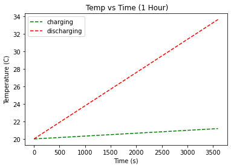

```python
# Purpose: To model Thermal Cooling and heating of a lithium ion battery during charging.
# written for a single sony 18650 cell

# --------------- Here we will list variables-----------------------
import numpy as np
import matplotlib.pyplot as plt
from decimal import *

getcontext().prec = 8

def solve_temp (current,time):
    ''' Inputs: current : decimal, time: interger
        outputs:  returns numpy array of time and T_f '''

    # initializing variables
    r = Decimal(.013)  # Resistance in Ohms
    m = Decimal(.044)  # Mass of battery in kg
    t_i = Decimal(20)  # initial Temperature of Battery (room temp celsius)
    t_f = Decimal(0)  # Final temperature of Battery (will be solving for this )
    c = Decimal(902)  # Specific heat capacity in Joules per kg celsius
    time_array = np.array([])
    temp_array = np.array([])
    for t in range(1,time):
        step_1 = current ** 2
        step_2 = step_1 * r
        step_3 = step_2 / m
        step_4 = step_3 / c
        t_f = t_i + step_4
        t_i = t_f
        time_array = np.append(time_array, [t])
        temp_array = np.append(temp_array, [t_f])
        t+= 1

    return time_array, temp_array


time = 3600  # time (our iterable) in seconds
current =  [Decimal(1), Decimal(3.4)]  # Current in Amps recommend to be 1A charging and 3.4 Amps discharge
charging = solve_temp(current[0], time)
discharge = solve_temp(current[1],time)

plt.figure()

plt .subplot().set(xlabel = 'Time (s)', ylabel = 'Temperature (C)', title = ' Temp vs Time (1 Hour)', )
plt.plot(charging[0], charging[1] , "g--", label = "charging")
#plt.subplot().set(xlabel = 'Time (s)', ylabel = 'Temperature (C)', title = ' Discharging',)
plt.plot(discharge[0],discharge[1],"r--",label = "discharging")
plt.legend()
plt.show()
```

#### References and Citations

Used for specific heat of battery https://prod-ng.sandia.gov/techlib-noauth/access-control.cgi/2004/046721.pdf

Musings on places to go: Getting biot savart stuff in there, newtons cooling of course, enthalpy, Then how does resistance change over temperature. Pick arbitrary constant for cooling coeficient.